# Clustering

Jindra

12/1/2017

### Setup

```r
suppressMessages(library(dplyr))
library(tidyr)
```

```r
library(ggplot2)
library(mlbench)
```

## Clustering

Clustering methods seek to find similarities between data points and group data according to these similarities. Such clusters can either have a hierarchical structure or not; when the structure is hierarchical, each data point will be associated with several clusters, ordered from the more specific to the more general, and when the structure is not hierarchical any data point is typically only assigned a single cluster.

### k-means clustering

In k-means clustering you attempt to separate the data into k clusters, where you determine the number k. The method will work as long as you have a way of computing the mean of a set of data points and the distance between pairs of data points

```r
clusters <- iris %>%
  select(-Species) %>% #only numerical data can be used
  kmeans(centers = 3)

#centers and clusters are the most interesting parameters
clusters$centers
```

```
##   Sepal.Length Sepal.Width Petal.Length Petal.Width
## 1     6.850000    3.073684     5.742105    2.071053
## 2     5.901613    2.748387     4.393548    1.433871
## 3     5.006000    3.428000     1.462000    0.246000
```

```r
clusters$cluster %>% head
```

```
## [1] 3 3 3 3 3 3
```

```r
clusters$cluster %>% table #sums points in each cluster
```

```
## .
##  1  2  3
## 38 62 50
```

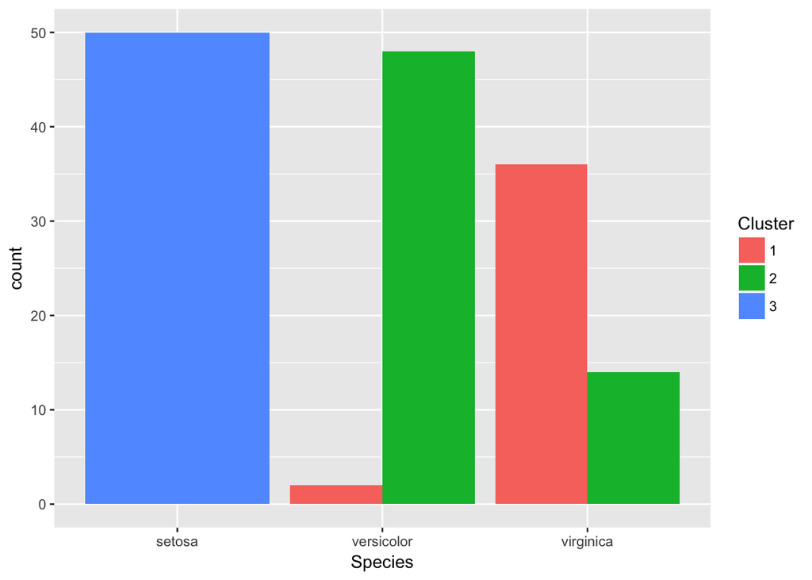

```r
#how many data points from each species are assigned to each cluster
iris %>%
  cbind(Cluster = clusters$cluster) %>%
  ggplot() +
  geom_bar(aes(x = Species, fill = as.factor(Cluster)),
           position = "dodge") +
  #"dodge" results are plotted next to each other not stacked on top of each other
  scale_fill_discrete("Cluster")
```

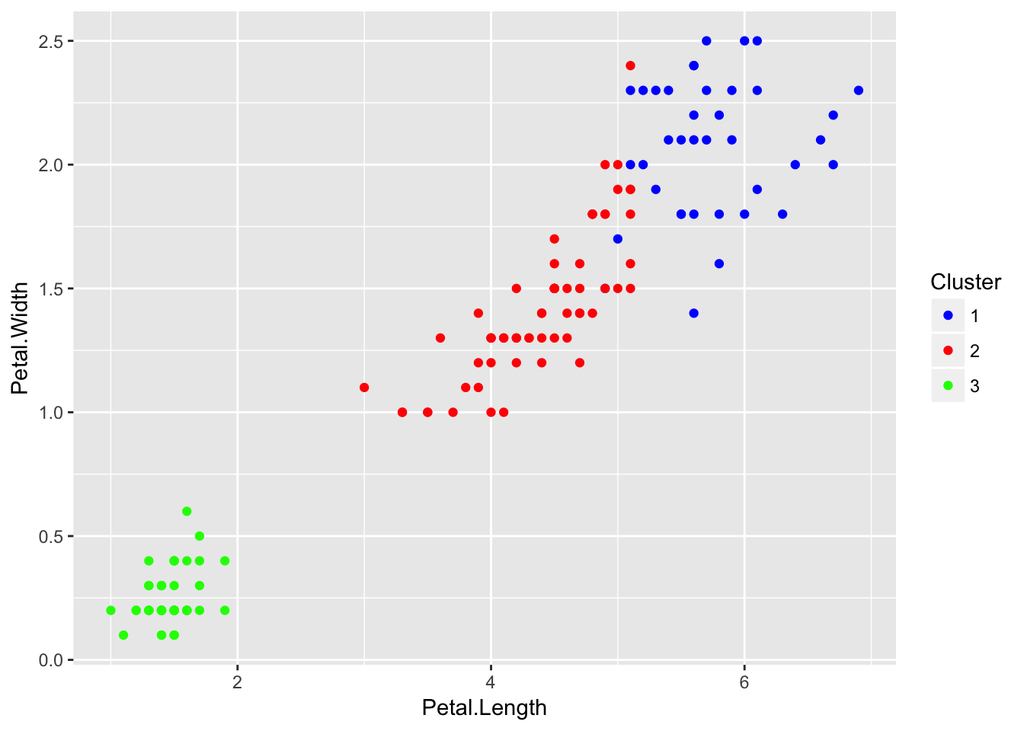

```r
data("iris")
iris %>%
  ggplot(aes(x = Petal.Length,
             y = Petal.Width,
             colour = as.factor(clusters$cluster))) +
  scale_colour_manual("Cluster", values = c("1" = "blue",
                                            "2" = "red",
                                            "3" = "green")) +
  geom_point()
```